# Classification: trees and random forests

Ellis Valentiner

April 9, 2015

# Classification trees

Classification trees are a method commonly used in data mining. They are popular becase they are *easy to interpret* and reflect how (some) decisions are made.

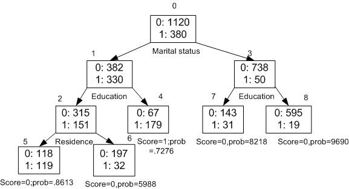

# Classification trees

The basic idea is to (recursively) divide the feature space into regions and fit a simple ‘model’ for each region.

**Details:**

- Grow in top-down fasion (divisive) by choosing the split that optimizies the criterion (greedy).
- Grow a large tree and then prune it at the end.

We can estimate the probability that the class label is $k$ given that the feature vector lies in region $M$.

# Some things to consider:

**How do we choose the best splits?**

We want splits that best separate our class labels.

**How large do we grow the tree (when do we stop splitting?)**

We want the number of observations in the terminal node to be reasonably large otherwise we are just modeling noise.

**Stopping rules:**

1. If all observations belong to the same class.
2. Too few observations to continue splitting.

# Split criterions

There are several different methods for choosing the best split.

- Misclassification error
- Gini
- Cross-entropy (deviance)

# Misclassification error

The proportion of the observations in that region that do not belong to the most common class.

$\text{Error} = 1 - \text{max}(\hat{p}_{mk})$

# Gini

Measures the total variance across the $K$ classes.

Small values indicates that a node contains predominantly observations from a single class (i.e. small variation).

Attempts to separate classes by focusing on one class at a time. It will always favor working on the largest or, if you use costs or weights, the most “important” class in a node.

$\text{Gini} = \overset{K}{\underset{k = 1}{\Sigma}} \hat{p}_{mk} (1 - \hat{p}_{mk})$

# Cross-entropy (deviance)

Similar measure of node purity where small values also indicate node purity (like Gini).

Instead of separating one class at a time entropy tends to separate groups of classes, each accounting for roughly 50% of the observations.

Results in more evenly balanced trees.

$\text{Deviance} = -\overset{K}{\underset{k = 1}{\Sigma}} \hat{p}_{mk} \text{log} \hat{p}_{mk}$

# So which split criterion should you use?

It doesn’t really matter. Different split criterions usually give similar performance.

The `tree` package uses defaults to deviance; `random forests` uses Gini.

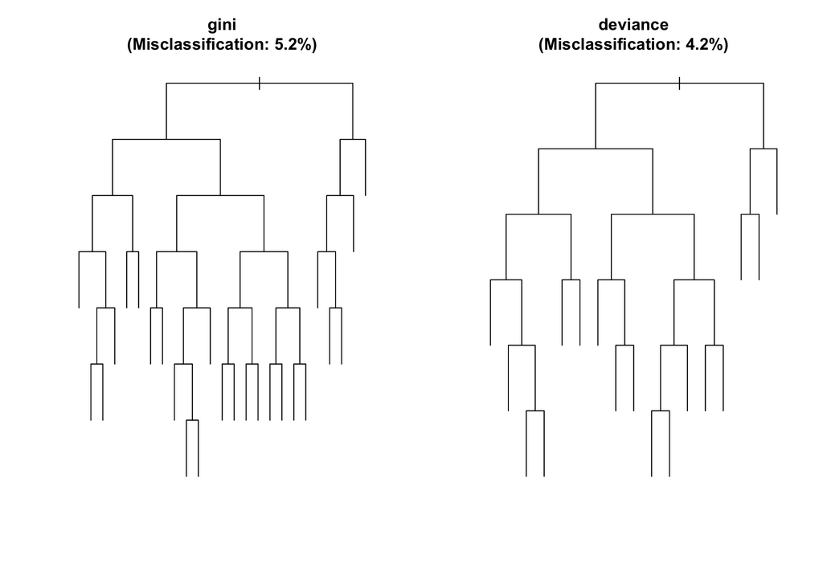

# Two-dimensional example

```r
# Summary of dataset
summary(train_data)
```

```
##     Group           X1                X2
##  Orange:297   Min.   :-0.9804   Min.   :-0.96966
##  Blue  :203   1st Qu.:-0.3941   1st Qu.:-0.34460
##               Median : 0.1148   Median : 0.09573
##               Mean   : 0.1261   Mean   : 0.07507
##               3rd Qu.: 0.6584   3rd Qu.: 0.52230
##               Max.   : 1.1442   Max.   : 1.11792
```

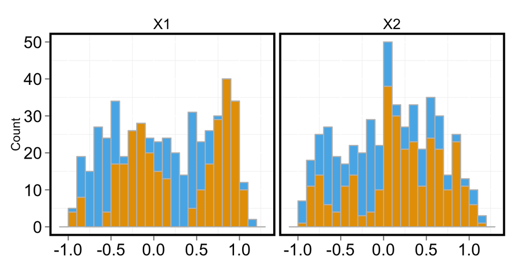

# Two-dimensional example

```r
# Print random 5 rows
head(train_data[sample(nrow(train_data)),])
```

```
##      Group          X1         X2
## 110   Blue  0.35868128 -0.1638366
## 45  Orange -0.34901851  0.1246819
## 66  Orange  0.90250625  0.5254130
## 438 Orange  0.05070714  0.6575863
## 324 Orange  0.76363161  0.1595582
## 14  Orange  0.81636073  0.2001557
```

# Fitting the tree

```r
# Load the `tree` package
library(tree)
# Fit the classification tree
tree_fit <- tree(Group ~ X1 + X2, data = train_data)
# Model summary
summary(tree_fit)
```

```
##
## Classification tree:
## tree(formula = Group ~ X1 + X2, data = train_data)
## Number of terminal nodes:  17
## Residual mean deviance:  0.242 = 116.9 / 483
## Misclassification error rate: 0.042 = 21 / 500
```

```r
# Plot the dendrogram
plot(tree_fit, type = 'uniform')
# Add split labels
text(tree_fit)
```

[output not shown]

# Dendrogram

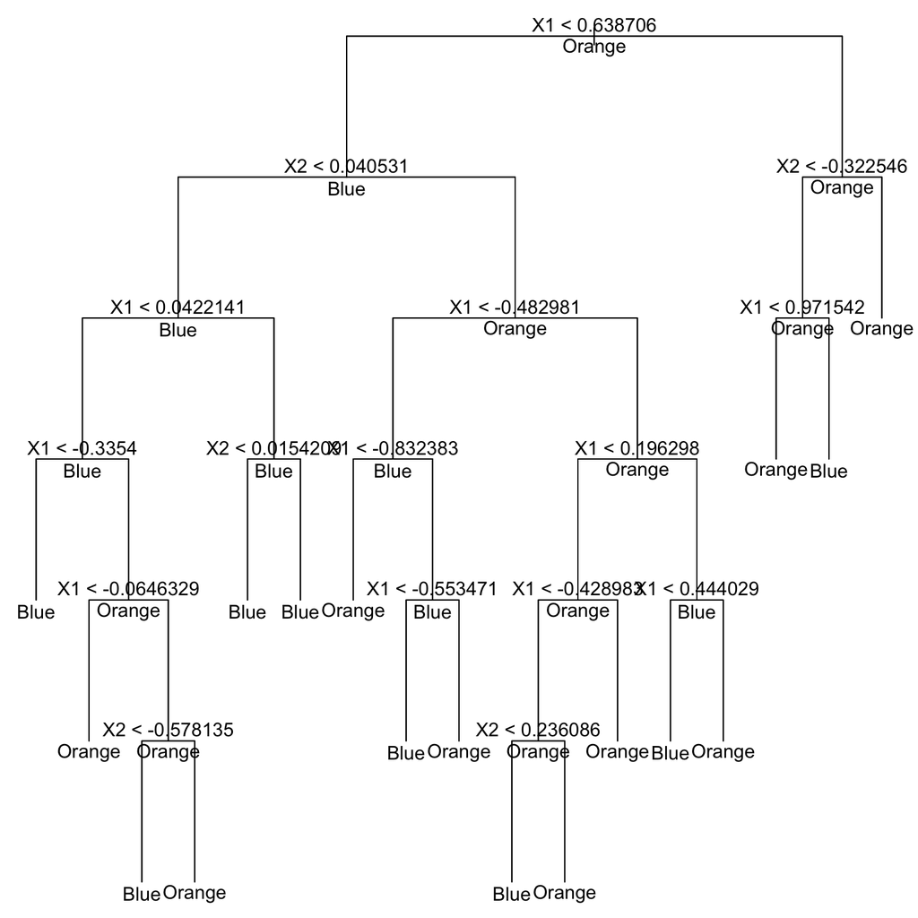

```r
# Plot the dendrogram
plot(tree_fit, type = 'uniform')
# Add split labels
text(tree_fit, all = TRUE)
```

# Two-dimensional example: No splits

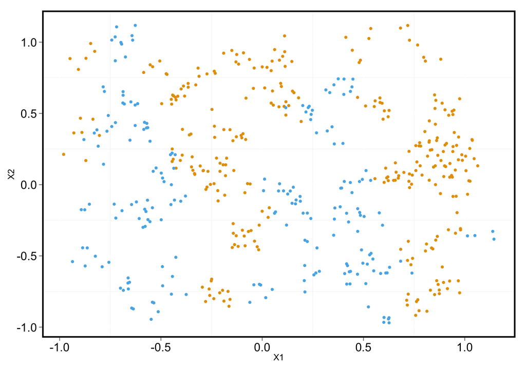

# Two-dimensional example: 1 split

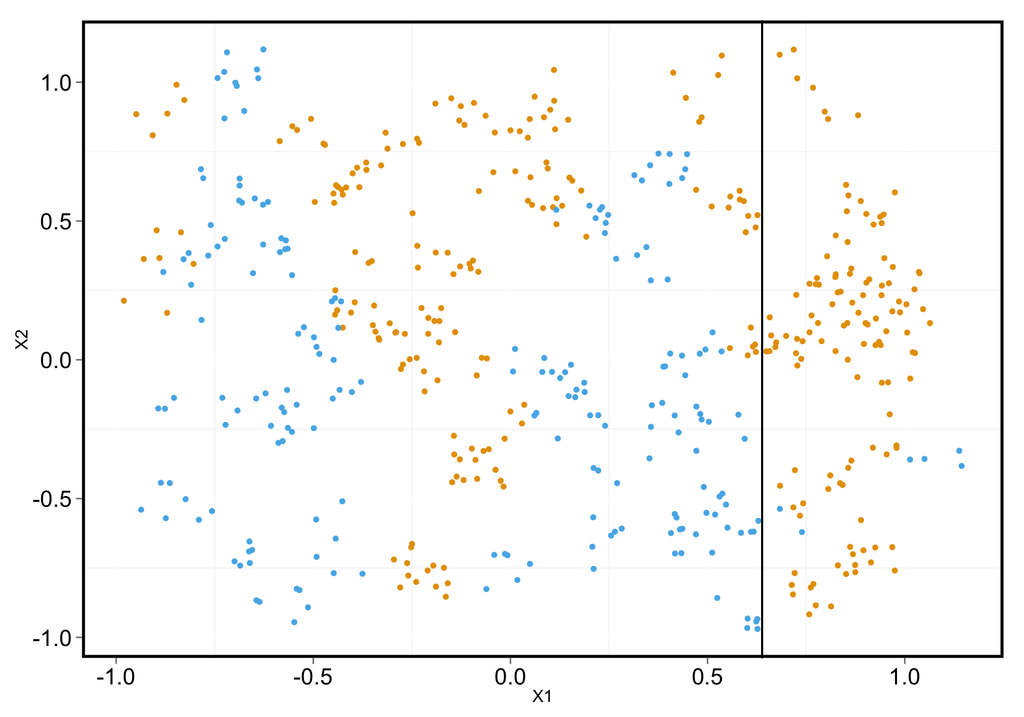

# Two-dimensional example: 2 splits

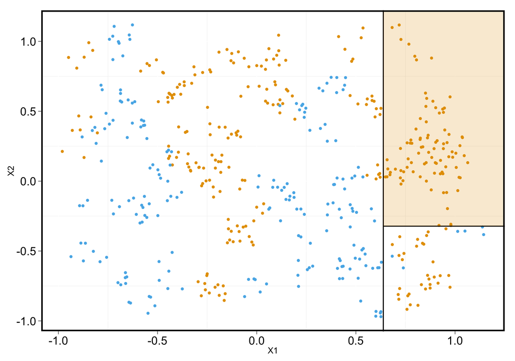

# Two-dimensional example: 3 splits

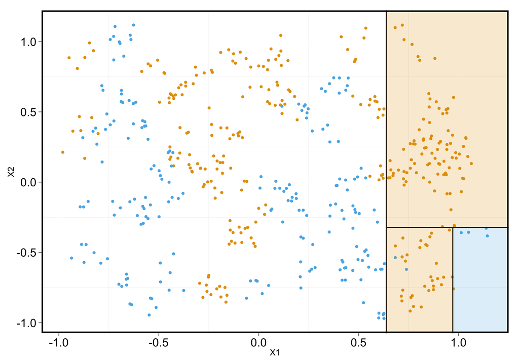

# Two-dimensional example: 4 splits

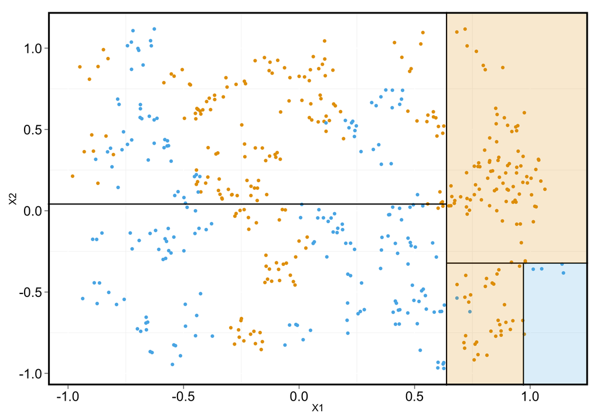